# GR5243-Project_1-Tianlun Lin

## Question Interested

*Question*: What is the effect of health on happiness of single and married people, respectively?

## Analyese for Orginial Data

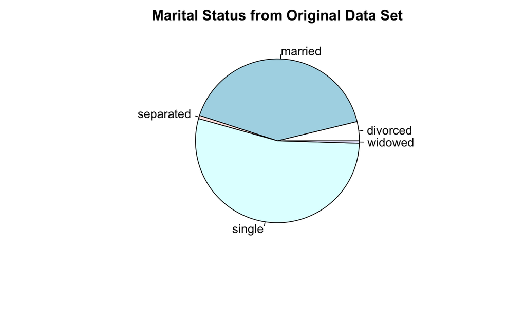

From the pie chart above, one can observe that most people in the data set can be categorized to either “single” or “married”. Moreover, there also exist other groups, while the proportion of such groups are limited compared to the biggest two groups. Thus, when doing the following analysis, we only focus on the groups of “single” and “married” people.

## General Analysis between Happiness and Health

To observe the meanings of words much clearer, we can “lemmatize” the sentences according to words’ nature.

Now, we hope to obtain the words most similar to health and happiness respectively. The result can be represented in a plot using the output of word2vec model.

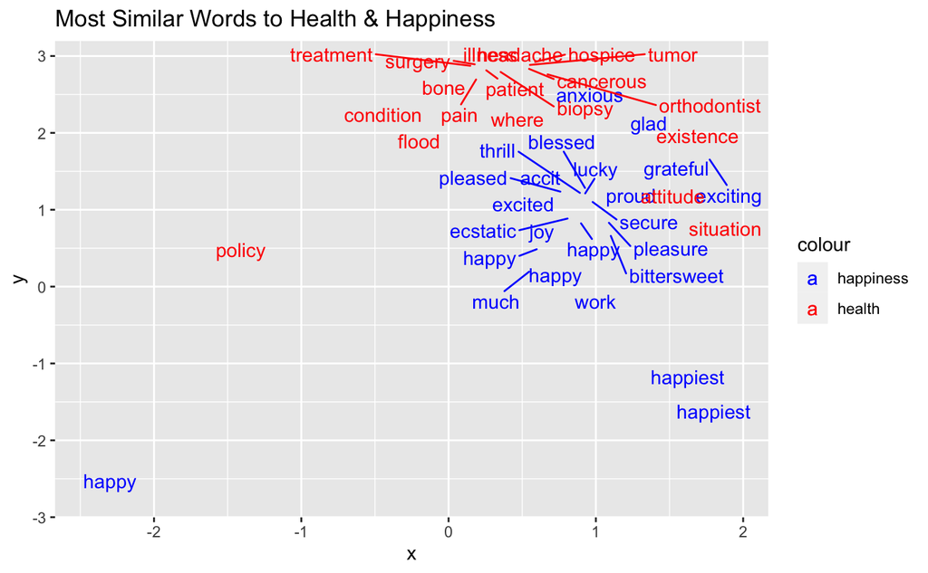

From the plot above, we can observe that there is a correlation between the words about “health” and happiness of people to some extend since the two clusters of points are relatively close to each other.

## Apply Word2vec Model to “Single” Group and “Married” Group

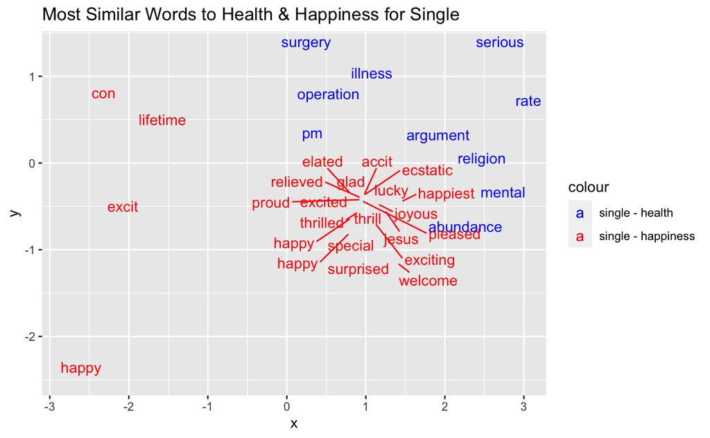

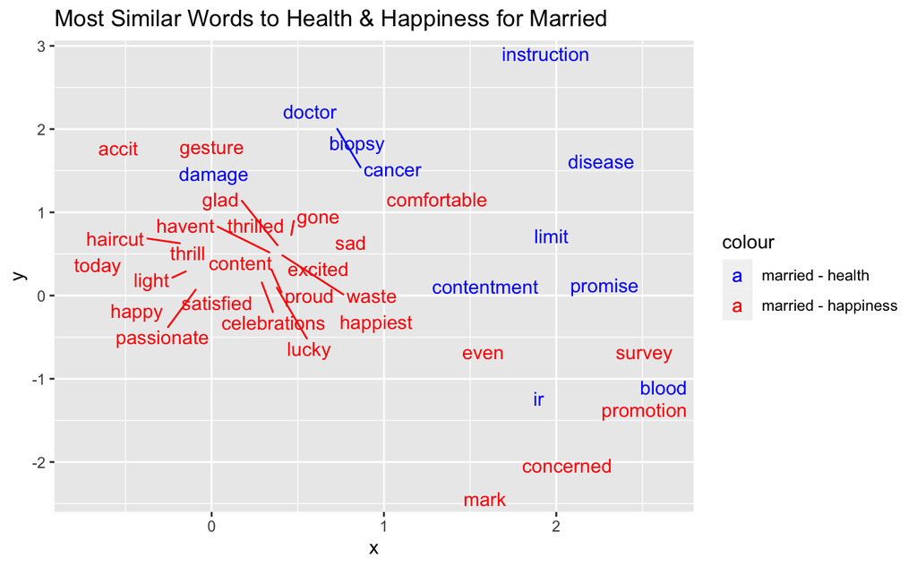

## Colclusion

From the overall plot in the second section, we can claim that there should be a relationship between “health” word and “happiness” words. Moreover, by comparing the resulted umap plot for both single people and married people, we can observe that health seems to be a topic that more correlated to the group of married people since the clusters of words representing “health” and “happiness” are more closed to each other.